# Term Deposit Subscription

### Data Set:

bank-full

### Objective:

Using the data collected from existing customers, build a model that will help the marketing team identify potential customers who are relatively more likely to subscribe term deposit and thus increase their hit ratio.

## Load Libaries and Data

```python
import warnings
warnings.filterwarnings('ignore')
```

```python
#Load Libraries
import pandas as pd
import numpy as np
import matplotlib
import matplotlib.pyplot as plt
import seaborn as sns
%matplotlib inline

sns.set(color_codes=True)
from sklearn.model_selection import train_test_split
from sklearn.linear_model import LogisticRegression
from sklearn import metrics
```

```python
#Load data
Term_Deposit_df = pd.read_csv('bank-full.csv')
```

## Exploratory Data Analysis:

```python
#Determine if there are any missing values. The number of variables, whether numeric and/or string and the total number of rows.
Term_Deposit_df.info()
```

```
<class 'pandas.core.frame.DataFrame'>
RangeIndex: 45211 entries, 0 to 45210
Data columns (total 17 columns):
 #   Column     Non-Null Count  Dtype
---  ------     --------------  -----
 0   age        45211 non-null  int64
 1   job        45211 non-null  object
 2   marital    45211 non-null  object
 3   education  45211 non-null  object
 4   default    45211 non-null  object
 5   balance    45211 non-null  int64
 6   housing    45211 non-null  object
 7   loan       45211 non-null  object
 8   contact    45211 non-null  object
 9   day        45211 non-null  int64
 10  month      45211 non-null  object
 11  duration   45211 non-null  int64
 12  campaign   45211 non-null  int64
 13  pdays      45211 non-null  int64
 14  previous   45211 non-null  int64
 15  poutcome   45211 non-null  object
 16  Target     45211 non-null  object
dtypes: int64(7), object(10)
memory usage: 5.9+ MB
```

### Check Datatypes

```python
#Check the data type for each attribute column within the csv file.
Term_Deposit_df.dtypes
```

```
age           int64
job          object
marital      object
education    object
default      object
balance       int64
housing      object
loan         object
contact      object
day           int64
month        object
duration      int64
campaign      int64
pdays         int64
previous      int64
poutcome     object
Target       object
dtype: object
```

### Header and top 5 rows of file

```python
##Print header of the file
Term_Deposit_df.head()
```

|  | age | job | marital | education | default | balance | housing | loan | contact | day | month | duration | campaign | pdays | previous | poutcome | Target |
| --- | --- | --- | --- | --- | --- | --- | --- | --- | --- | --- | --- | --- | --- | --- | --- | --- | --- |
| 0 | 58 | management | married | tertiary | no | 2143 | yes | no | unknown | 5 | may | 261 | 1 | -1 | 0 | unknown | no |
| 1 | 44 | technician | single | secondary | no | 29 | yes | no | unknown | 5 | may | 151 | 1 | -1 | 0 | unknown | no |
| 2 | 33 | entrepreneur | married | secondary | no | 2 | yes | yes | unknown | 5 | may | 76 | 1 | -1 | 0 | unknown | no |
| 3 | 47 | blue-collar | married | unknown | no | 1506 | yes | no | unknown | 5 | may | 92 | 1 | -1 | 0 | unknown | no |
| 4 | 33 | unknown | single | unknown | no | 1 | no | no | unknown | 5 | may | 198 | 1 | -1 | 0 | unknown | no |

### Statistical Summary

```python
##Summary Statistics of data
Term_Deposit_df.describe().T
```

|  | count | mean | std | min | 25% | 50% | 75% | max |
| --- | --- | --- | --- | --- | --- | --- | --- | --- |
| age | 45211.0 | 40.936210 | 10.618762 | 18.0 | 33.0 | 39.0 | 48.0 | 95.0 |
| balance | 45211.0 | 1362.272058 | 3044.765829 | -8019.0 | 72.0 | 448.0 | 1428.0 | 102127.0 |
| day | 45211.0 | 15.806419 | 8.322476 | 1.0 | 8.0 | 16.0 | 21.0 | 31.0 |
| duration | 45211.0 | 258.163080 | 257.527812 | 0.0 | 103.0 | 180.0 | 319.0 | 4918.0 |
| campaign | 45211.0 | 2.763841 | 3.098021 | 1.0 | 1.0 | 2.0 | 3.0 | 63.0 |
| pdays | 45211.0 | 40.197828 | 100.128746 | -1.0 | -1.0 | -1.0 | -1.0 | 871.0 |
| previous | 45211.0 | 0.580323 | 2.303441 | 0.0 | 0.0 | 0.0 | 0.0 | 275.0 |

### Confirm Number of Records

```python
##Provide dimension of data

print('Number of features in the data : ', Term_Deposit_df.shape[1])
print('Number of samples in the data  : ', Term_Deposit_df.shape[0])
```

```
Number of features in the data :  17
Number of samples in the data  :  45211
```

### Check for null values

```python
#Gives the sum of null values.
Term_Deposit_df.isna().sum()
```

```
age          0
job          0
marital      0
education    0
default      0
balance      0
housing      0
loan         0
contact      0
day          0
month        0
duration     0
campaign     0
pdays        0
previous     0
poutcome     0
Target       0
dtype: int64
```

```python
print(Term_Deposit_df["job"].value_counts())
print("*"*25)
print(Term_Deposit_df["marital"].value_counts())
print("*"*25)
print(Term_Deposit_df["education"].value_counts())
```

```
blue-collar      9732
management       9458
technician       7597
admin.           5171
services         4154
retired          2264
self-employed    1579
entrepreneur     1487
unemployed       1303
housemaid        1240
student           938
unknown           288
Name: job, dtype: int64
married     27214
single      12790
divorced     5207
Name: marital, dtype: int64
secondary    23202
tertiary     13301
primary       6851
unknown       1857
Name: education, dtype: int64
```

```python
print(Term_Deposit_df["Target"].value_counts())
```

```
no     39922
yes     5289
Name: Target, dtype: int64
```

From the distribution shown above we can see that the data is imbalanced since the number of "no" far outwiegh the number of "yes"

### Distribution of Target Variable

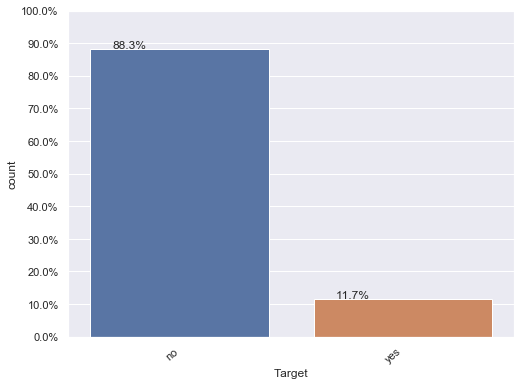

```python
plt.figure(figsize=(8,6))
Y = Term_Deposit_df["Target"]
total = len(Y)*1.
ax=sns.countplot(x="Target", data=Term_Deposit_df)
for p in ax.patches:
    ax.annotate('{:.1f}%'.format(100*p.get_height()/total), (p.get_x()+0.1, p.get_height()+5))

#put 11 ticks (therefore 10 steps), from 0 to the total number of rows in the dataframe
ax.yaxis.set_ticks(np.linspace(0, total, 11))
#adjust the ticklabel to the desired format, without changing the position of the ticks.
ax.set_yticklabels(map('{:.1f}%'.format, 100*ax.yaxis.get_majorticklocs()/total))
ax.set_xticklabels(ax.get_xticklabels(), rotation=40, ha="right")
# ax.legend(labels=["no","yes"])
plt.show()
```

```python
def countplot(label, dataset):
  plt.figure(figsize=(15,10))
  Y = Term_Deposit_df[label]
  total = len(Y)*1.
  ax=sns.countplot(x=label, data=Term_Deposit_df)
  for p in ax.patches:
    ax.annotate('{:.1f}%'.format(100*p.get_height()/total), (p.get_x()+0.1, p.get_height()+5))

  #put 11 ticks (therefore 10 steps), from 0 to the total number of rows in the dataframe
  ax.yaxis.set_ticks(np.linspace(0, total, 11))
  #adjust the ticklabel to the desired format, without changing the position of the ticks.
  ax.set_yticklabels(map('{:.1f}%'.format, 100*ax.yaxis.get_majorticklocs()/total))
  ax.set_xticklabels(ax.get_xticklabels(), rotation=40, ha="right")
  # ax.legend(labels=["no","yes"])
  plt.show()
```

```python
%matplotlib inline

def countplot_withTarget(label, Term_Deposit_df):
  plt.figure(figsize=(20,10))
  Y = Term_Deposit_df[label]
  total = len(Y)*1.
  ax=sns.countplot(x=label, data=Term_Deposit_df, hue="Target")
  for p in ax.patches:
    ax.annotate('{:.1f}%'.format(100*p.get_height()/total), (p.get_x()+0.1, p.get_height()+5))

  #put 11 ticks (therefore 10 steps), from 0 to the total number of rows in the dataframe
  ax.yaxis.set_ticks(np.linspace(0, total, 11))
  #adjust the ticklabel to the desired format, without changing the position of the ticks.
  ax.set_yticklabels(map('{:.1f}%'.format, 100*ax.yaxis.get_majorticklocs()/total))
  ax.set_xticklabels(ax.get_xticklabels(), rotation=40, ha="right")
  # ax.legend(labels=["no","yes"])
  plt.show()
```

## Features - Categorical

### Job

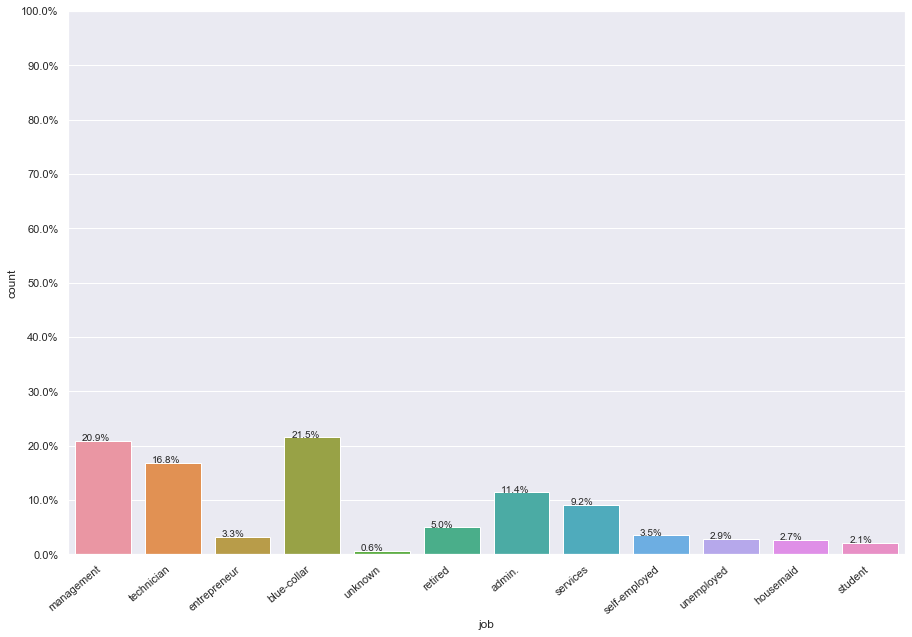

```python
countplot("job", Term_Deposit_df)
```

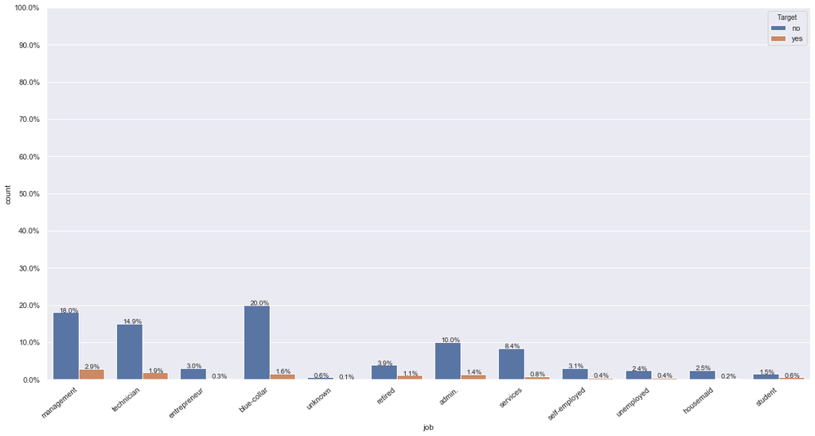

```python
countplot_withTarget("job", Term_Deposit_df)
```

At this point we are not sure if there is any correlation between job and target variable.

### Marital Status

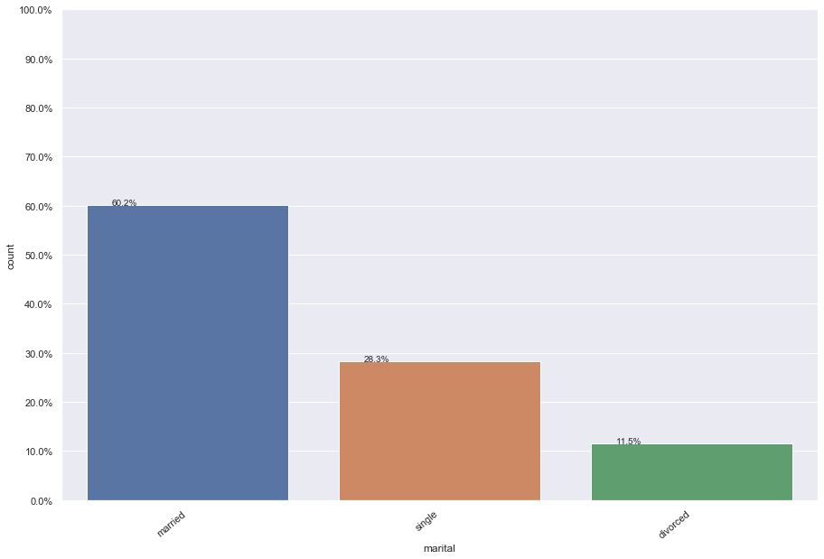

```python
countplot("marital", Term_Deposit_df)
```

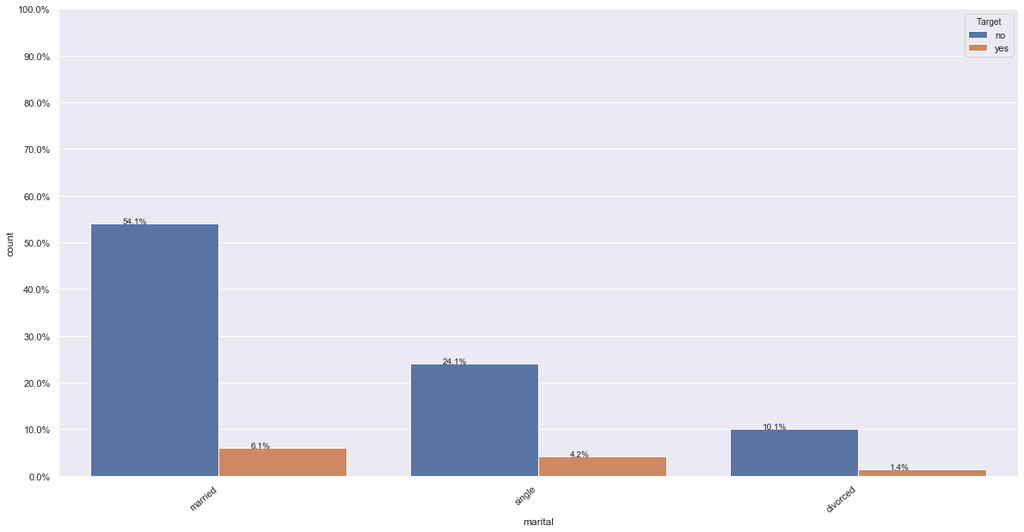

```python
countplot_withTarget("marital", Term_Deposit_df)
```

### Default

Outlines if whether or not credit is in default

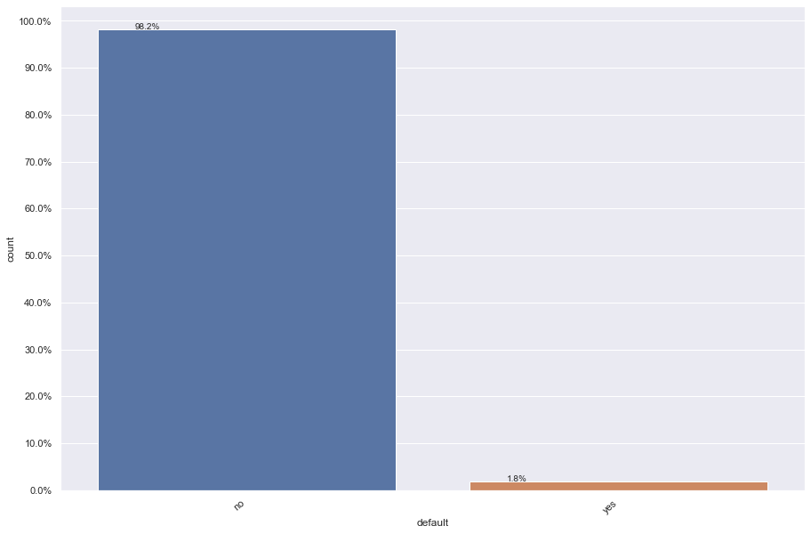

```python
countplot("default", Term_Deposit_df)
```

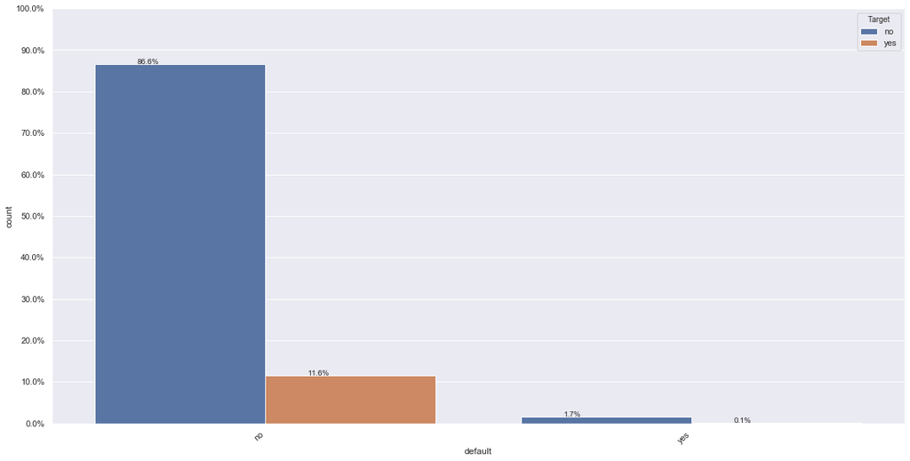

```python
countplot_withTarget("default", Term_Deposit_df)
```

There is a small percentage who have credit in default. The vast majority of the customers don't have.

### Education

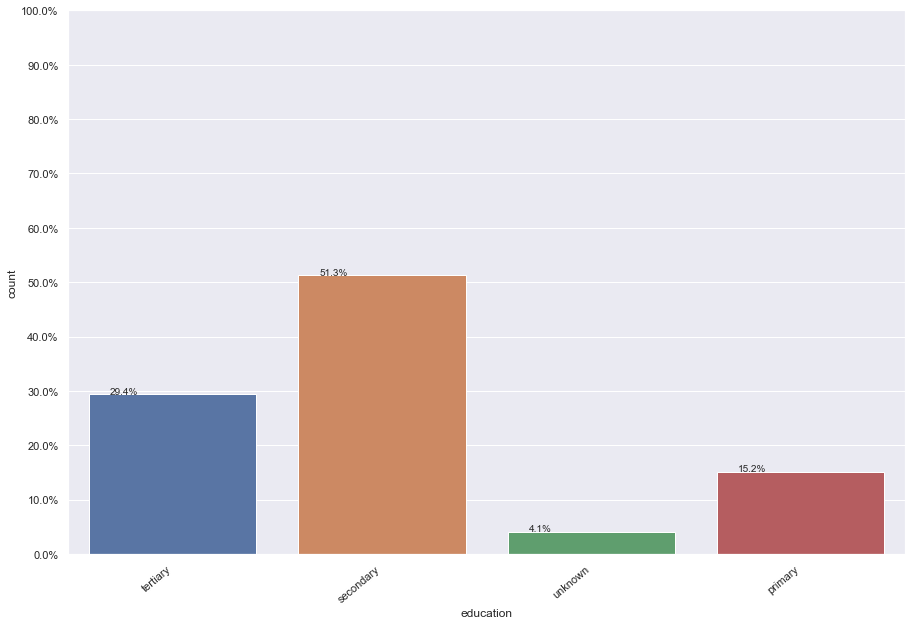

```python
countplot("education",Term_Deposit_df)
```

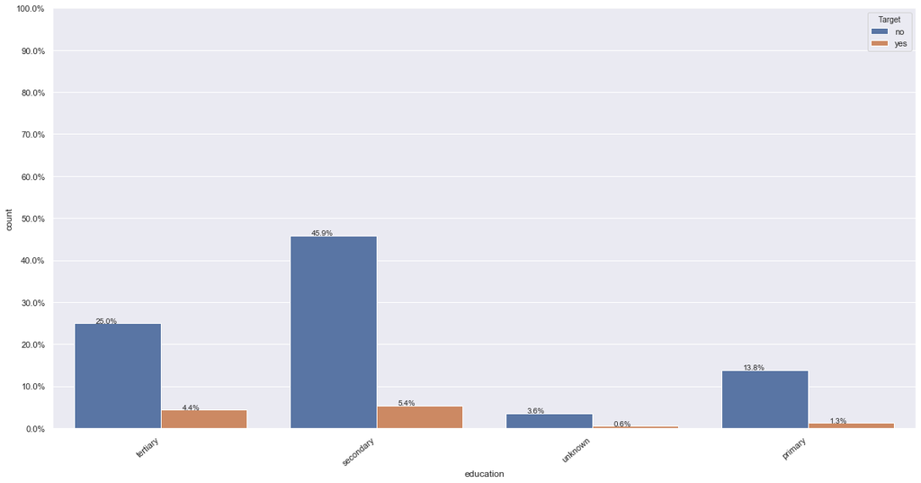

```python
countplot_withTarget("education", Term_Deposit_df)
```

### Housing

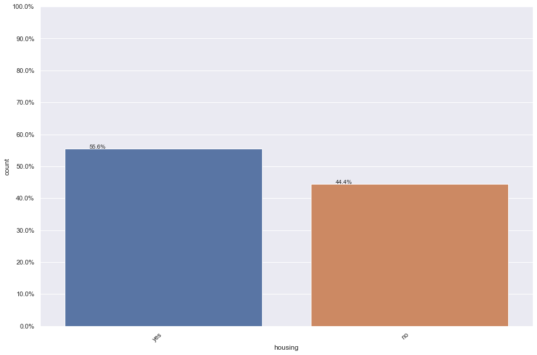

```python
countplot("housing", Term_Deposit_df)
```

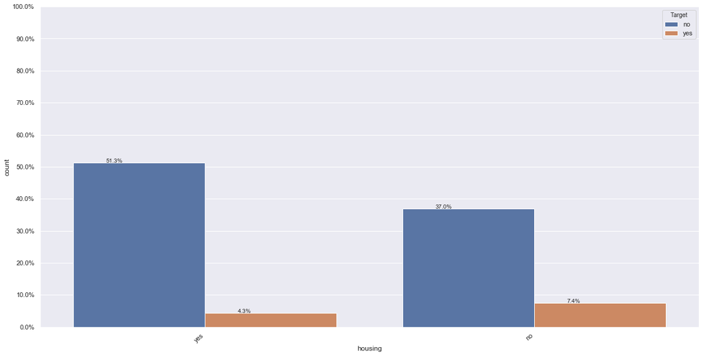

```python
countplot_withTarget("housing", Term_Deposit_df)
```

### Loan

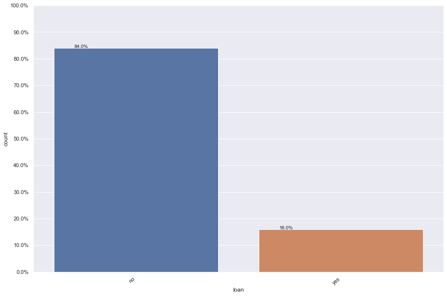

```python
countplot("loan", Term_Deposit_df)
```

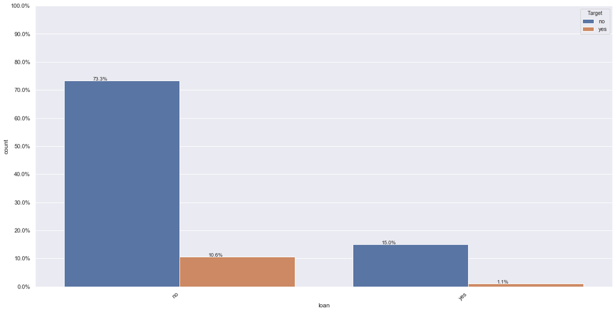

```python
countplot_withTarget("loan", Term_Deposit_df)
```

### Contact

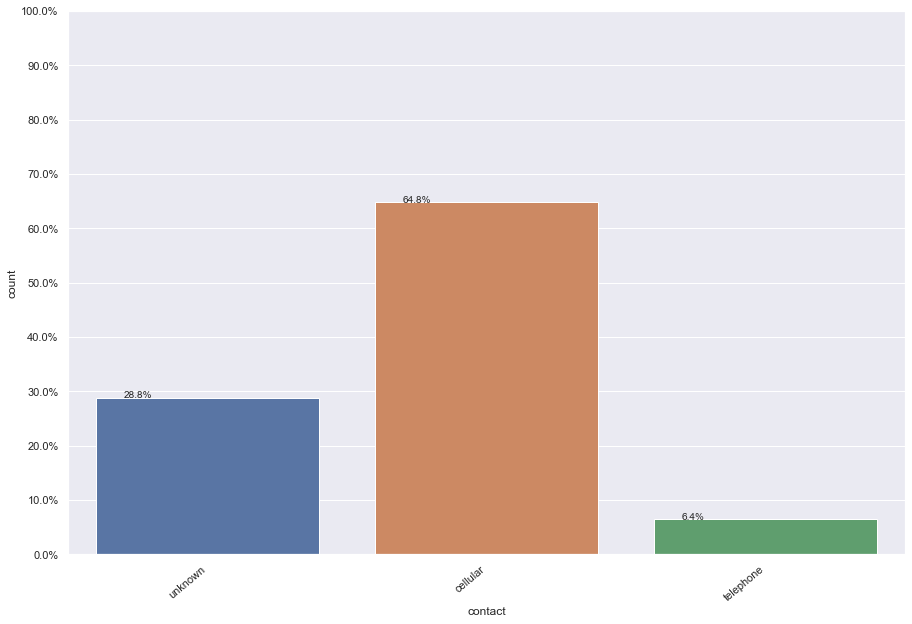

```python
countplot("contact", Term_Deposit_df)
```

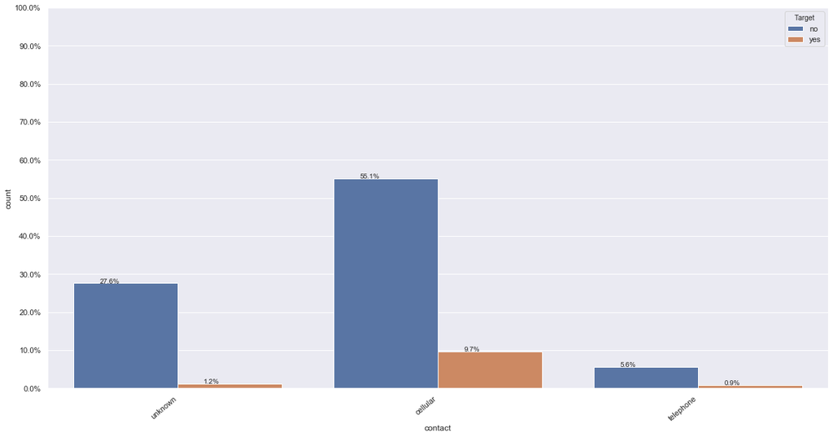

```python
countplot_withTarget("contact", Term_Deposit_df)
```

### Month

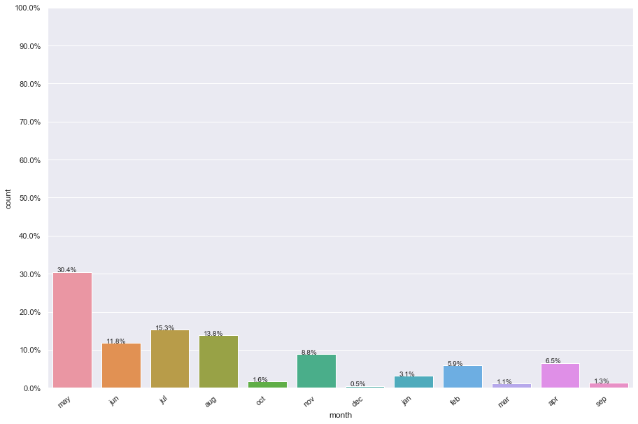

```python
countplot("month", Term_Deposit_df)
```

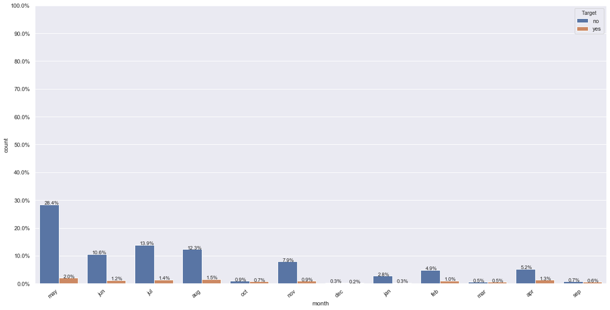

```python
countplot_withTarget("month", Term_Deposit_df)
```

### Day

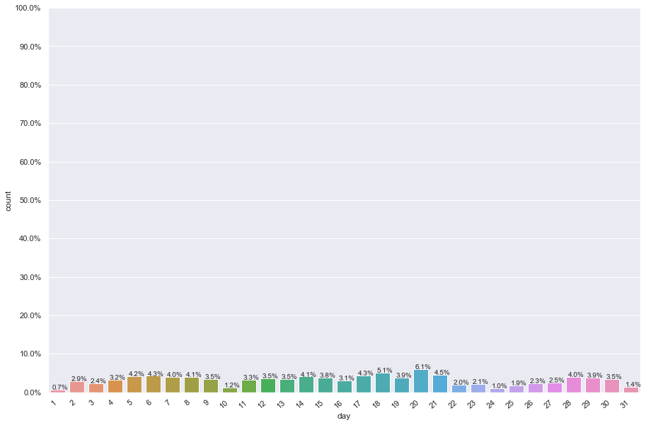

```python
countplot("day", Term_Deposit_df)
```

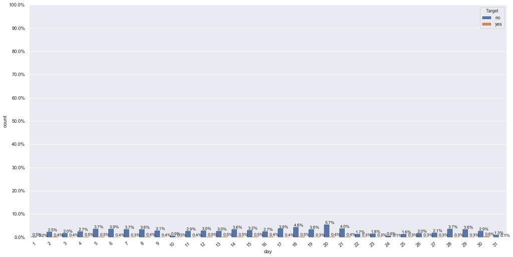

```python
countplot_withTarget("day", Term_Deposit_df)
```

### Poutcome

Shows the outcome of the previous campaign.

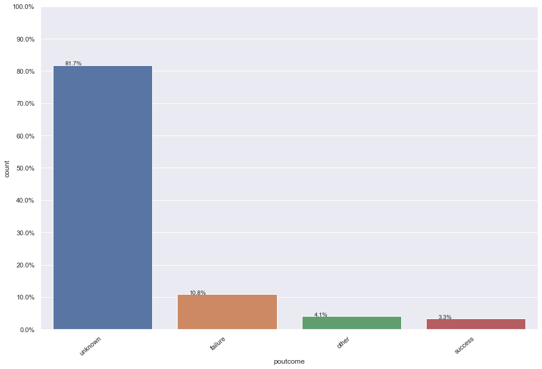

```python
countplot("poutcome", Term_Deposit_df)
```

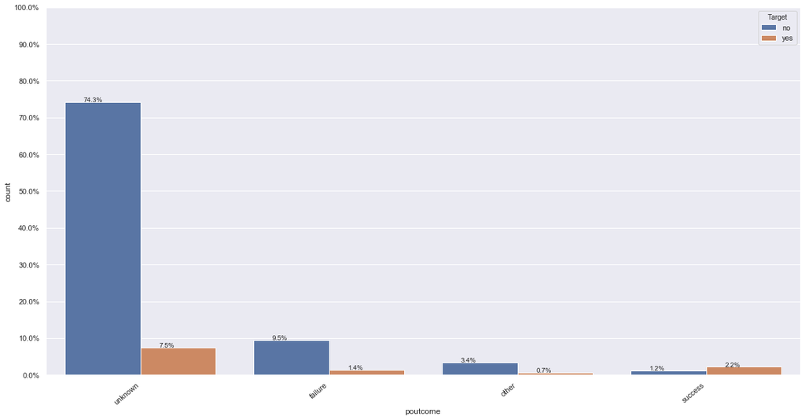

```python
countplot_withTarget("poutcome", Term_Deposit_df)
```

## Features - Numeric

### Age

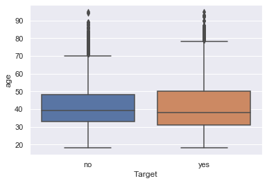

```python
%matplotlib inline
sns.boxplot(data=Term_Deposit_df, x="Target", y="age")
plt.show()
```

Median age of around 38-40 hold true for who did or didn't subscribe for a term deposit. The boxes tend to overlap which indictaes that age may not be a good indicator for which customer will subscribe or not.

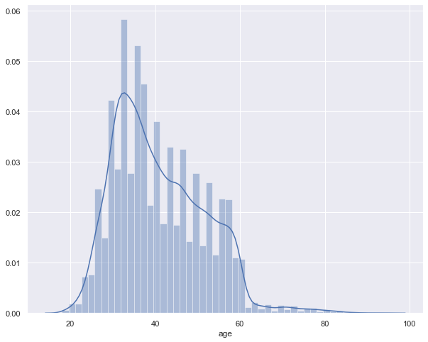

```python
plt.figure(figsize=(10,8))
sns.distplot(Term_Deposit_df["age"])
```

### Duration

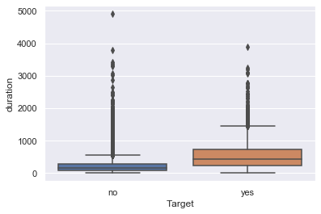

```python
%matplotlib inline
sns.boxplot(data=Term_Deposit_df, x="Target", y="duration")
plt.show()
```

From the above plot we can see that the last contact (duration) of a customer could be useful for predicting the target variable.

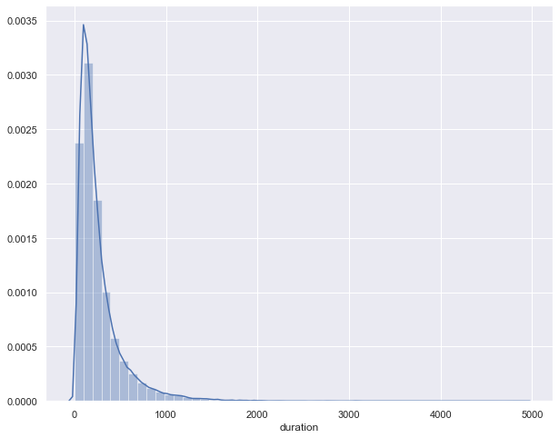

```python
plt.figure(figsize=(10,8))
sns.distplot(Term_Deposit_df["duration"])
plt.show()
```

### Campaign

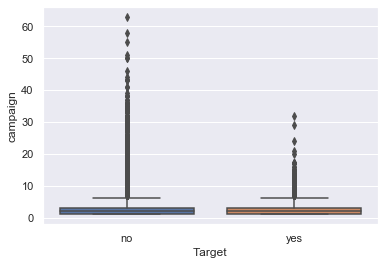

```python
%matplotlib inline
sns.boxplot(data=Term_Deposit_df, x="Target", y="campaign")
plt.show()
```

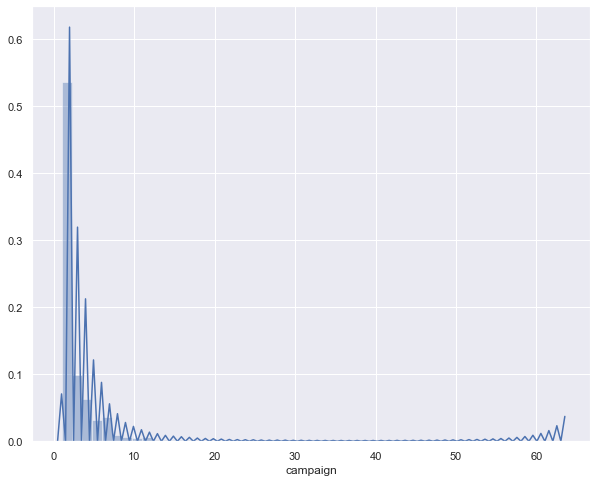

```python
%matplotlib inline
plt.figure(figsize=(10,8))
sns.distplot(Term_Deposit_df["campaign"])
plt.show()
```

### Pdays

```python
Term_Deposit_df["pdays"].unique()
```

[output not shown]

[output cut: 28 more lines]

```python
Term_Deposit_df["pdays"].value_counts()
```

```
-1      36954
 182      167
 92       147
 183      126
 91       126
        ...
 749        1
 717        1
 589        1
 493        1
 32         1
Name: pdays, Length: 559, dtype: int64
```

Most of the values are -1, which indictaes that the most of the customers have not been contacted before.

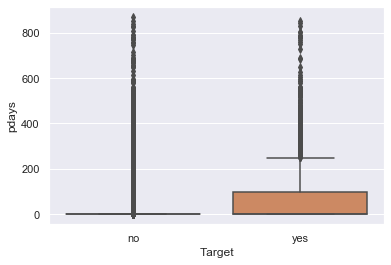

```python
%matplotlib inline
sns.boxplot(data=Term_Deposit_df, x="Target", y="pdays")
plt.show()
```

[output not shown]

[output cut: 13 more lines]

[output not shown]

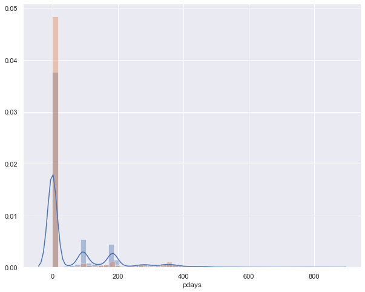

```python
%matplotlib inline
plt.figure(figsize=(10,8))
sns.distplot(Term_Deposit_df[Term_Deposit_df["Target"]=="yes"]["pdays"])
sns.distplot(Term_Deposit_df[Term_Deposit_df["Target"]=="no"]["pdays"])
plt.show()
```

### Previous

```python
Term_Deposit_df["previous"].unique()
```

```
array([  0,   3,   1,   4,   2,  11,  16,   6,   5,  10,  12,   7,  18,
         9,  21,   8,  14,  15,  26,  37,  13,  25,  20,  27,  17,  23,
        38,  29,  24,  51, 275,  22,  19,  30,  58,  28,  32,  40,  55,
        35,  41])
```

```python
Term_Deposit_df["previous"].value_counts()
```

```
0      36954
1       2772
2       2106
3       1142
4        714
5        459
6        277
7        205
8        129
9         92
10        67
11        65
12        44
13        38
15        20
```

[output cut: 27 more lines]

```python
Term_Deposit_df[Term_Deposit_df["Target"]=="yes"]["previous"].value_counts()
```

```
0     3384
1      583
2      456
3      294
4      171
5      121
6       83
7       54
8       39
10      26
9       24
11      15
12      10
13       9
14       5
17       3
19       2
20       1
15       1
58       1
30       1
21       1
29       1
23       1
22       1
26       1
55       1
Name: previous, dtype: int64
```

```python
Term_Deposit_df[Term_Deposit_df["Target"]=="no"]["previous"].value_counts()
```

```
0      33570
1       2189
2       1650
3        848
4        543
5        338
6        194
7        151
8         90
9         68
11        50
10        41
12        34
13        29
15        19
```

[output cut: 25 more lines]

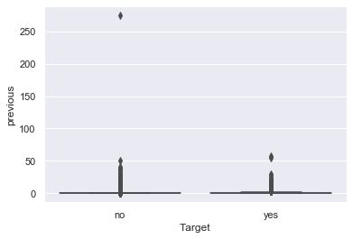

```python
%matplotlib inline
sns.boxplot(data=Term_Deposit_df, x="Target", y="previous")
plt.show()
```

[output not shown]

[output cut: 13 more lines]

[output not shown]

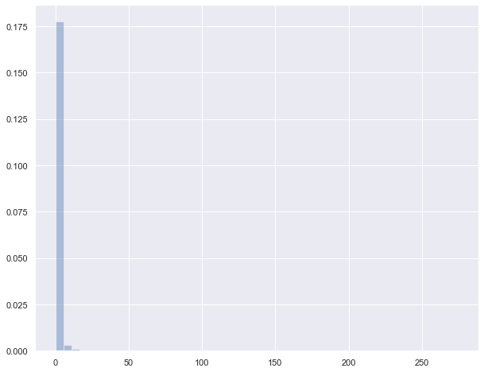

```python
%matplotlib inline
plt.figure(figsize=(10,8))
sns.distplot(Term_Deposit_df["previous"])
plt.show()
```